# Riding the Shadow

Mitchell Borchers

12/19/2020

## Introduction

While mountain biking one clear December evening there was a beautiful sunset. Entranced by the beauty a friend lost focus and rode off the trail. Asked later about the cause of the accident, the culprit was a distracting question. How fast would a person have to climb vertically from the surface of the Earth to always see the Sun just about to set on the horizon while the Earth is rotating?

## Assumptions

To simplify the problem, a few assumptions will be made. Assume:

- The point of reference (person) is positioned at the equator
- The Earth is rotating away from the Sun at a constant rate
- The Sun is treated like a point light source
- The point of reference is always rotating at the same speed as the Earth

## Setup

$$\begin{align*}
\sin(\alpha) &= \frac{r_e}{d_1} \\
\alpha &= \sin^{-1}(\frac{r_e}{d_1}) \\
\alpha &\approx 0
\end{align*}$$

$$\begin{align}
\cos(\phi) &= \frac{r_e}{r_e+l}\nonumber \\
r_e+l &= \frac{r_e}{cos(\phi)}\nonumber \\
l &= r_e\left(\frac{1}{cos(\phi)}-1\right)\nonumber \\
l(\phi) &= r_e\left(\frac{1}{cos(\phi)}-1\right)
\end{align}$$

In order to find the velocity time needs to be factored into the equation. This can be done using the constant rate of the rotation of the Earth denoted by $\omega$ measured in radians per second. The equation for angular velocity can be used to determine what to substitute in for the angle $\phi$ as shown.

$$\begin{align*}
\omega &= \frac{v_e}{r_e}
\end{align*}$$

Now instead of using the constant $\phi$, $\omega$ is changing over time and the length of the ladder $l$ can be calculated based on time $t$ where $t_0$ $\rightarrow$ $\phi=0$ and $t_f$ $\rightarrow$ $\phi=\frac{\pi}{2}$. The height equation can be rewritten relative to time as shown and the domain can be changed to $t$ where $t_0=0$ and (t_f=6) hours.

$$\begin{align}
l(t)=r_{e}\left(\frac{1}{cos\left(\frac{v_{e}}{r_{e}} t\right)}-1\right)
\end{align}$$

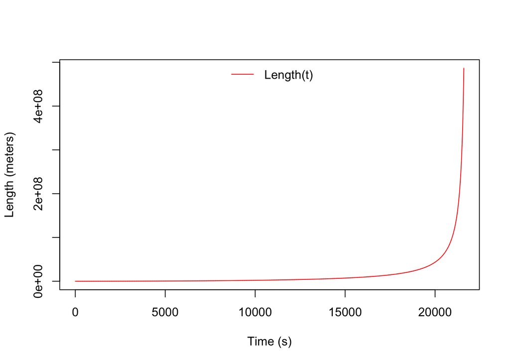

Taking the derivative of the position equation gives the velocity equation.

$$\begin{align}
l'(t)=v_e tan\left(\frac{v_e}{r_e}t\right)sec\left(\frac{v_e}{r_e} t\right)
\end{align}$$

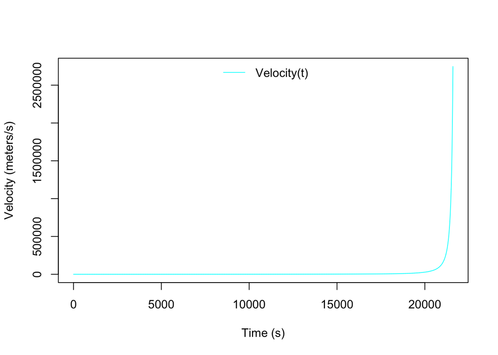

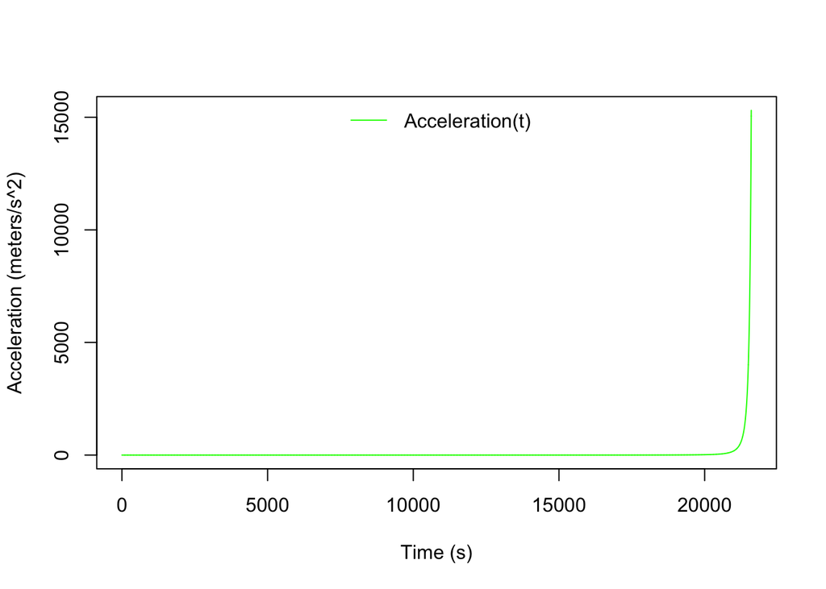